# Project: Communicate Data Findings (The loan data from prosper)

- Introduction
- Data Wrangling
- Exploratory Data Analysis
- Conclusions

## Introduction

### the loan data from prosper which related the Business sectore

### so the Questions are

#### Q1-What factors affect a loan’s outcome status?

#### Q2-What is the variables which affect prosper grade for a given borrower ?

#### Q3- what is the effect of the income range and the monthly income on the status of loan ?

#### Q4-Is there a realation between the loan amount ,Occuption and home owner ?

#### Q5-what is the most popular loan type ?

#### Q6-Is there a realation between term prosper score?

## Data Wrangling

### General Properties

Because there are many variables we creat the data frame which have the interested variable we want

```python
loan_data=df[['Term','LoanStatus','BorrowerAPR','BorrowerRate','LenderYield','EstimatedEffectiveYield'
            ,'ProsperScore','ListingCategory (numeric)','Occupation','IsBorrowerHomeowner','DebtToIncomeRatio'
            ,'IncomeRange','StatedMonthlyIncome','LoanKey','LoanOriginalAmount','LoanOriginationQuarter'
            ,'Investors']].copy()
```

```python
loan_data.head()
```

|  | Term | LoanStatus | BorrowerAPR | BorrowerRate | LenderYield | EstimatedEffectiveYield | ProsperScore | ListingCategory (numeric) | Occupation | IsBorrowerHomeowner | DebtToIncomeRatio | IncomeRange | StatedMonthlyIncome | LoanKey | LoanOriginalAmount | LoanOriginationQuarter | Investors |
| --- | --- | --- | --- | --- | --- | --- | --- | --- | --- | --- | --- | --- | --- | --- | --- | --- | --- |
| 0 | 36 | Completed | 0.16516 | 0.1580 | 0.1380 | NaN | NaN | 0 | Other | True | 0.17 | $25,000-49,999 | 3083.333333 | E33A3400205839220442E84 | 9425 | Q3 2007 | 258 |
| 1 | 36 | Current | 0.12016 | 0.0920 | 0.0820 | 0.07960 | 7.0 | 2 | Professional | False | 0.18 | $50,000-74,999 | 6125.000000 | 9E3B37071505919926B1D82 | 10000 | Q1 2014 | 1 |
| 2 | 36 | Completed | 0.28269 | 0.2750 | 0.2400 | NaN | NaN | 0 | Other | False | 0.06 | Not displayed | 2083.333333 | 6954337960046817851BCB2 | 3001 | Q1 2007 | 41 |
| 3 | 36 | Current | 0.12528 | 0.0974 | 0.0874 | 0.08490 | 9.0 | 16 | Skilled Labor | True | 0.15 | $25,000-49,999 | 2875.000000 | A0393664465886295619C51 | 10000 | Q4 2012 | 158 |
| 4 | 36 | Current | 0.24614 | 0.2085 | 0.1985 | 0.18316 | 4.0 | 2 | Executive | True | 0.26 | $100,000+ | 9583.333333 | A180369302188889200689E | 15000 | Q3 2013 | 20 |

```python
loan_data=loan_data.rename(columns={"ListingCategory (numeric)": "ListingCategory"})
```

0 - Not Available, 1 - Debt Consolidation, 2 - Home Improvement, 3 - Business, 4 - Personal Loan, 5 - Student Use, 6 - Auto, 7- Other, 8 - Baby&Adoption, 9 - Boat, 10 - Cosmetic Procedure, 11 - Engagement Ring, 12 - Green Loans, 13 - Household Expenses, 14 - Large Purchases, 15 - Medical/Dental, 16 - Motorcycle, 17 - RV, 18 - Taxes, 19 - Vacation, 20 - Wedding Loans

```python
numeric_List=[0,1,2,3,4,5,6,7,8,9,10,11,12,13,14,15,16,17,18,19,20]
string_value=['Not Available','Debt Consolidation','Home Improvemen','Business','Personal Loan','Student Use',
             'Auto','Other','Baby&Adoption','Boat','Cosmetic Procedure','Engagement Ring','Green Loans',
             'Household Expenses','Large Purchases','Medical/Denta','Motorcycle','RV','Taxes','Vacation','Wedding Loans']
loan_data['ListingCategory']=loan_data.ListingCategory.replace(numeric_List,string_value)
```

```python
loan_data.describe()
```

|  | Term | BorrowerAPR | BorrowerRate | LenderYield | EstimatedEffectiveYield | ProsperScore | DebtToIncomeRatio | StatedMonthlyIncome | LoanOriginalAmount | Investors |
| --- | --- | --- | --- | --- | --- | --- | --- | --- | --- | --- |
| count | 113937.000000 | 113912.000000 | 113937.000000 | 113937.000000 | 84853.000000 | 84853.000000 | 105383.000000 | 1.139370e+05 | 113937.00000 | 113937.000000 |
| mean | 40.830248 | 0.218828 | 0.192764 | 0.182701 | 0.168661 | 5.950067 | 0.275947 | 5.608026e+03 | 8337.01385 | 80.475228 |
| std | 10.436212 | 0.080364 | 0.074818 | 0.074516 | 0.068467 | 2.376501 | 0.551759 | 7.478497e+03 | 6245.80058 | 103.239020 |
| min | 12.000000 | 0.006530 | 0.000000 | -0.010000 | -0.182700 | 1.000000 | 0.000000 | 0.000000e+00 | 1000.00000 | 1.000000 |
| 25% | 36.000000 | 0.156290 | 0.134000 | 0.124200 | 0.115670 | 4.000000 | 0.140000 | 3.200333e+03 | 4000.00000 | 2.000000 |
| 50% | 36.000000 | 0.209760 | 0.184000 | 0.173000 | 0.161500 | 6.000000 | 0.220000 | 4.666667e+03 | 6500.00000 | 44.000000 |
| 75% | 36.000000 | 0.283810 | 0.250000 | 0.240000 | 0.224300 | 8.000000 | 0.320000 | 6.825000e+03 | 12000.00000 | 115.000000 |
| max | 60.000000 | 0.512290 | 0.497500 | 0.492500 | 0.319900 | 11.000000 | 10.010000 | 1.750003e+06 | 35000.00000 | 1189.000000 |

# check the Null values of data and replace null with coustom value based on the column data type

### Replace the null value with the mean in all numeric features

```python
loan_data['BorrowerAPR'].fillna((loan_data['BorrowerAPR'].mean()), inplace=True)
```

```python
loan_data['ProsperScore'].fillna((loan_data['ProsperScore'].mean()), inplace=True)
```

```python
loan_data['DebtToIncomeRatio'].fillna((loan_data['DebtToIncomeRatio'].mean()), inplace=True)
```

```python
loan_data['EstimatedEffectiveYield'].fillna((loan_data['EstimatedEffectiveYield'].mean()), inplace=True)
```

### Replace the null value witt other in Occupation feature

```python
loan_data['Occupation'].fillna('other', inplace=True)
```

## Exploratory Data Analysis

### Univariate of some features

### from the shape the most popular Occupations are Executive ,Computer programmer and Administrative Assistant without professional and the less popular occupations is student and judge

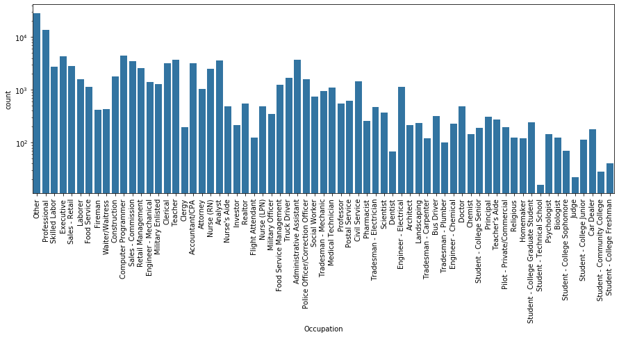

```python
base_color=sb.color_palette()[0]
plt.figure(figsize=[15,5])
sb.countplot(data=loan_data,x='Occupation',color=base_color)
plt.xticks(rotation=90)
plt.yscale('log')
```

### the popular Income Ranges are 25000-49999 and 50000-74999 which indiacte the most of Bank clintes in the middle Standard of living

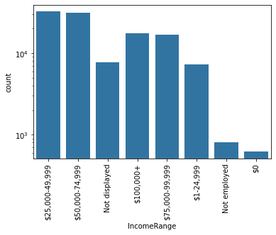

```python
sb.countplot(data=loan_data,x='IncomeRange',color=base_color)
plt.xticks(rotation=90)
plt.yscale('log')
```

### Debt Consolidation is the most popular type of loan so there may initially be a negative impact on the consumer's or the clinte credit score. and this consumer society and there the summation of the vacation,motrocycle and Auto type count assure this indiaction

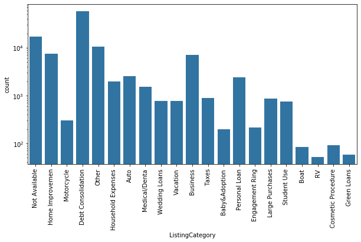

```python
plt.figure(figsize=[10,5])
sb.countplot(data=loan_data,x='ListingCategory',color=base_color)
plt.xticks(rotation=90)
plt.yscale('log')
```

### from this figure we can tell 2013 has the flourishment of the bank to Q1 2014

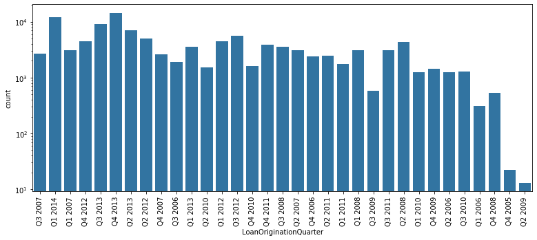

```python
plt.figure(figsize=[13,5])
sb.countplot(data=loan_data,x='LoanOriginationQuarter',color=base_color)
plt.xticks(rotation=90)
plt.yscale('log')
```

### this figure there is the probelm in the houseing

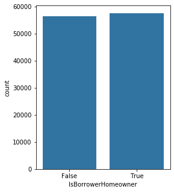

```python
plt.figure(figsize=[4,5])
sb.countplot(data=loan_data,x='IsBorrowerHomeowner',color=base_color)
```

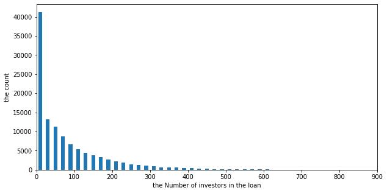

```python
Bin=np.arange(0,loan_data['Investors'].max()+1,20)
plt.figure(figsize=[10,5])
plt.hist(data=loan_data,x='Investors',bins=Bin,rwidth=.5,color=base_color)
#plt.yscale('log')
plt.xlim(0,900)
plt.xlabel(' the Number of investors in the loan ')
plt.ylabel('the count')
```

### the salary figure assure our induction from the income most of Bank clintes in the middle Standard of living

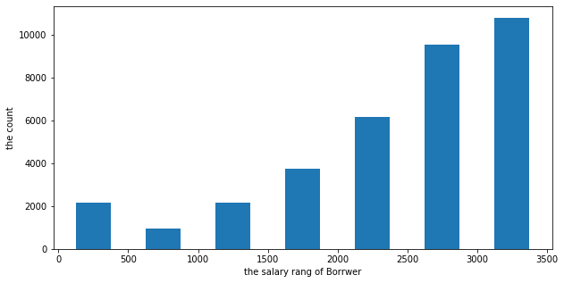

```python
Bin=np.arange(0,4000,500)
plt.figure(figsize=[10,5])
plt.hist(data=loan_data,x='StatedMonthlyIncome',bins=Bin,rwidth=.5,color=base_color)
plt.xlabel('the salary rang of Borrwer')
plt.ylabel('the count')
```

# Bivariate of some features

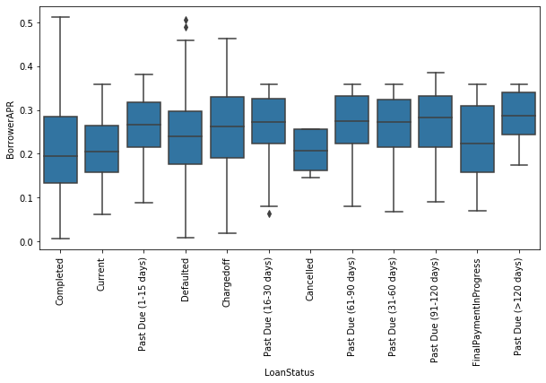

```python
plt.figure(figsize=[10,5])
sb.boxplot(data = loan_data, x = 'LoanStatus', y = 'BorrowerAPR', color = base_color)
plt.xticks(rotation=90)
```

### the most frequency occupations with the complete stauts is which have the heigh Income Range

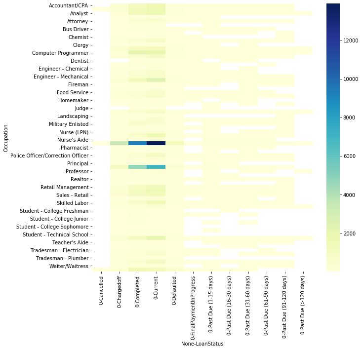

```python
plt.figure(figsize=[10,10])
sb.heatmap(Status_Occupation_counts,cmap="YlGnBu")
```

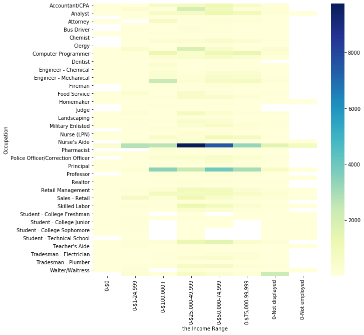

```python
plt.figure(figsize=[10,10])
sb.heatmap(Income_Occupation_counts,cmap="YlGnBu")
plt.xlabel('the Income Range')
```